# 市场观察

2017/04/17

## A、指数估值

### (a)动态市盈率、市净率

核心指数成分股近18个月的动态市盈率及动态市净率中位数走势如下图所示：

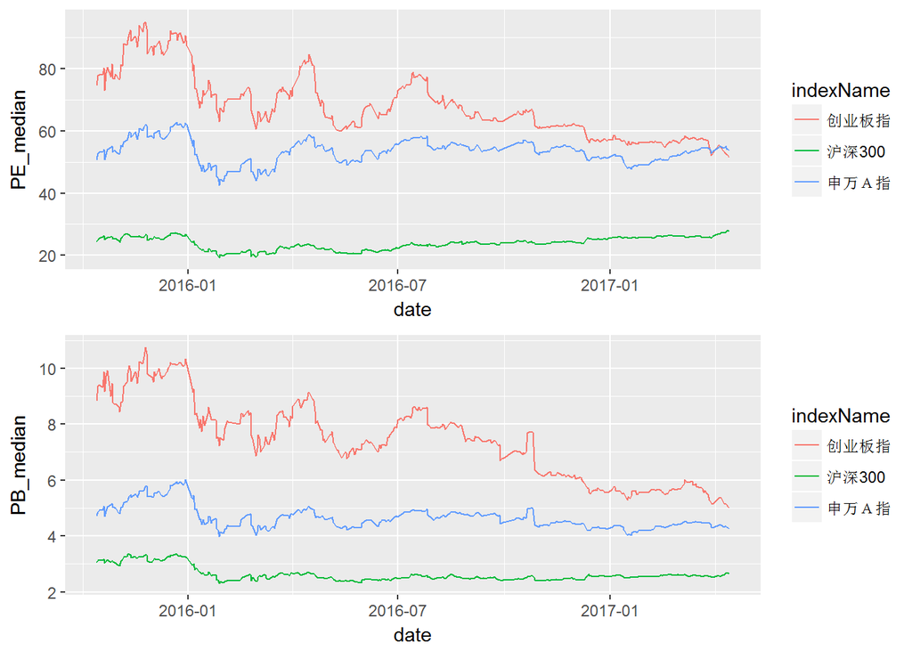

### (b)动态市盈率、市净率百分位

核心指数近18个月的动态市盈率百分位及动态市净率百分位走势如下图所示：

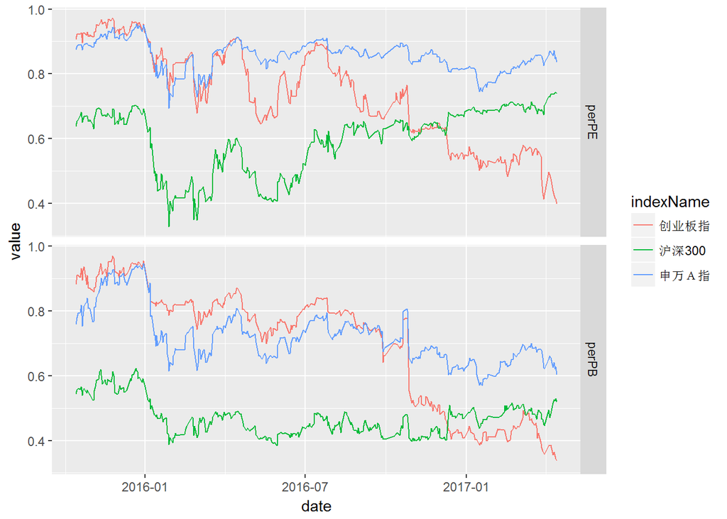

### (c)指数估值概览

| 指数代码 | 指数简称 | 日期 | 动态市盈率 | 市盈率百分位 | 动态市净率 | 市净率百分位 |
| --- | --- | --- | --- | --- | --- | --- |
| EI000979 | 大宗商品 | 2017-04-14 | 62.2 | 100% | 2.8 | 63% |
| EI000819 | 有色金属 | 2017-04-14 | 75.9 | 98% | 3.5 | 62% |
| EI801003 | 申万Ａ指 | 2017-04-14 | 53.5 | 84% | 4.2 | 60% |
| EI399959 | 军工指数 | 2017-04-14 | 90.0 | 74% | 5.5 | 67% |
| EI399330 | 深证100 | 2017-04-14 | 34.3 | 73% | 4.1 | 64% |
| EI000300 | 沪深300 | 2017-04-14 | 27.7 | 74% | 2.6 | 52% |
| EI000905 | 中证500 | 2017-04-14 | 40.5 | 66% | 3.2 | 43% |
| EI399005 | 中小板指P | 2017-04-14 | 40.2 | 60% | 4.7 | 45% |
| EI000934 | 中证金融 | 2017-04-14 | 20.2 | 70% | 1.9 | 24% |
| EI000827 | 中证环保 | 2017-04-14 | 40.5 | 58% | 3.2 | 35% |
| EI000922 | 中证红利 | 2017-04-14 | 17.2 | 53% | 1.8 | 38% |
| EI000016 | 上证50 | 2017-04-14 | 18.2 | 64% | 1.6 | 14% |
| EI399006 | 创业板指 | 2017-04-14 | 51.4 | 40% | 5.0 | 34% |
| EI000998 | 中证TMT | 2017-04-14 | 41.6 | 39% | 4.2 | 35% |
| EI000933 | 中证医药 | 2017-04-14 | 38.9 | 60% | 3.8 | 4% |
| EI000932 | 中证消费 | 2017-04-14 | 30.2 | 34% | 3.7 | 17% |

### (d)另类估值

我国10年期国债收益率、金银比价、金油比价，2000年以来的历史百分位如下图所示：

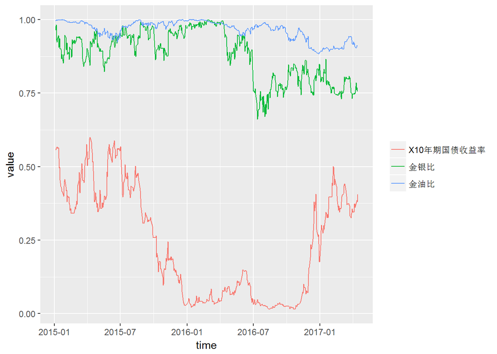

## B、基差

### (a)基差走势

三大股指期货合约基差走势如下图，其中当月合约和次月合约年化基差百分比波动较大，仅展示合约基差百分比，当季合约和次季合约展示基差年化百分比：

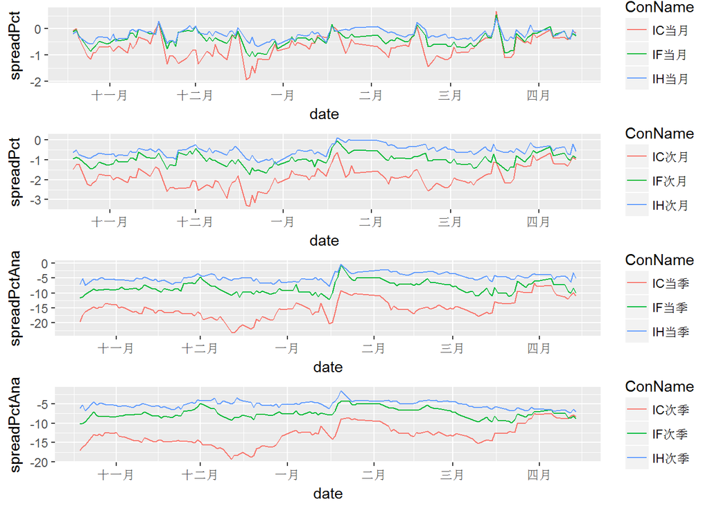

### (b)基差概况

三大股指期货连续合约基差概况如下表，近月合约临近到期日，年化基差百分比数据波动较大：

| 日期 | 合约代码 | 合约收盘价 | 指数收盘价 | 基差 | 基差百分比 | 年化基差百分比 |
| --- | --- | --- | --- | --- | --- | --- |
| 2017-04-14 | IC1704 | 6518.8 | 6528.2 | -9.4 | -0.1% | -7.8% |
| 2017-04-14 | IC1705 | 6464.0 | 6528.2 | -64.2 | -1.0% | -10.7% |
| 2017-04-14 | IC1706 | 6409.2 | 6528.2 | -119.0 | -1.8% | -11.0% |
| 2017-04-14 | IC1709 | 6305.0 | 6528.2 | -223.2 | -3.4% | -8.3% |
| 2017-04-14 | IF1704 | 3477.0 | 3486.5 | -9.5 | -0.3% | -15.3% |
| 2017-04-14 | IF1705 | 3454.8 | 3486.5 | -31.7 | -0.9% | -9.9% |
| 2017-04-14 | IF1706 | 3428.4 | 3486.5 | -58.1 | -1.7% | -10.0% |
| 2017-04-14 | IF1709 | 3359.2 | 3486.5 | -127.3 | -3.7% | -8.9% |
| 2017-04-14 | IH1704 | 2349.8 | 2355.5 | -5.7 | -0.2% | -13.5% |
| 2017-04-14 | IH1705 | 2342.0 | 2355.5 | -13.5 | -0.6% | -6.2% |
| 2017-04-14 | IH1706 | 2335.0 | 2355.5 | -20.5 | -0.9% | -5.2% |
| 2017-04-14 | IH1709 | 2287.0 | 2355.5 | -68.5 | -2.9% | -7.0% |

## C、套利和事件

### (a)复牌股票套利

近两天复牌股票套利情况如下表：

[1] “No valuation adjustment!”

[1] “无复牌股票套利”

### (b)定增基金(provided by han.qian)

截止2017-04-17定增基金数据如下表，明细数据参见钱瀚的模板。

| 代码 | 名称 | 到期日期 | 最新净值 | 昨日收盘价 | 折溢价率 | 整体隐含折价率 | 大盘下跌0.1净值变化 |
| --- | --- | --- | --- | --- | --- | --- | --- |
| 168101.OF | 九泰锐智 | 20200814 | 1.21 | 1.07 | -11.5% | 4.1% | -9.5% |
| 168102.OF | 九泰锐富 | 20210204 | 1.04 | 0.90 | -13.8% | 3.8% | -5.0% |
| 501015.OF | 财通升级 | 20170908 | 1.05 | 1.02 | -3.1% | 2.4% | -8.7% |
| 160518.OF | 博时睿远 | 20171016 | 1.00 | 0.95 | -5.1% | 1.9% | -6.1% |

定增基金近期的净值走势如下图：

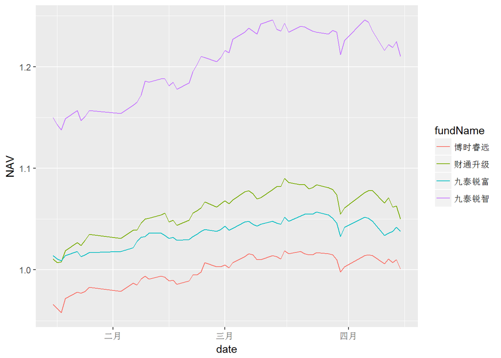

定增基金近期的折溢价率百分比走势如下图：

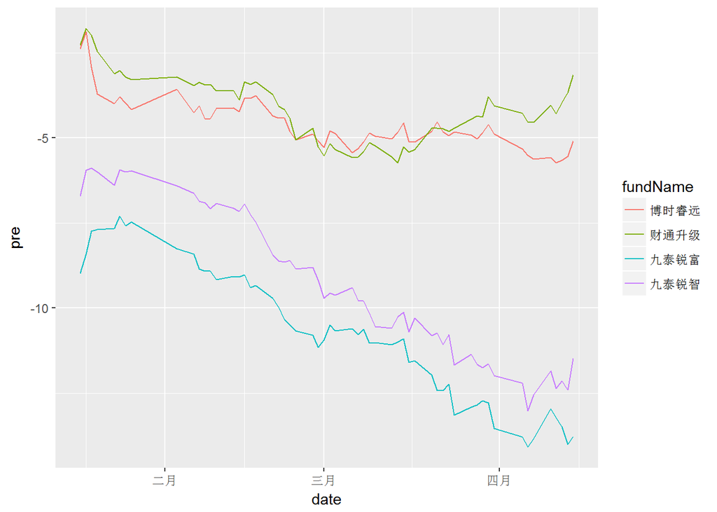

### (c)定增解禁(provided by han.qian)

近十天定增解禁的股票情况如下表。

| 股票代码 | 股票简称 | 起始跟踪日 | 解禁日 | 解禁百分比 | 区间涨跌幅 | 所属行业指数 | 行业指数涨跌幅 |
| --- | --- | --- | --- | --- | --- | --- | --- |
| EQ002139 | 拓邦股份 | 2017-03-29 | 2017-04-14 | 14% | -4.8% | 申万电子 | -3.9% |
| EQ002390 | 信邦制药 | 2017-03-29 | 2017-04-14 | 20% | -5.3% | 申万医药生物 | -2.6% |
| EQ002027 | 分众传媒 | 2017-03-30 | 2017-04-17 | 14% | 0.7% | 申万传媒 | -4.0% |
| EQ002248 | 华东数控 | 2017-03-30 | 2017-04-17 | 19% | 0.0% | 申万机械设备 | -2.1% |
| EQ300310 | 宜通世纪 | 2017-03-31 | 2017-04-18 | 13% | -2.4% | 申万通信 | -0.9% |
| EQ002380 | 科远股份 | 2017-04-05 | 2017-04-19 | 18% | -4.5% | 申万计算机 | -0.2% |
| EQ600525 | 长园集团 | 2017-04-05 | 2017-04-19 | 9% | -1.8% | 申万电气设备 | 0.9% |
| EQ000961 | 中南建设 | 2017-04-06 | 2017-04-20 | 27% | -4.8% | 申万房地产 | 3.7% |
| EQ000979 | 中弘股份 | 2017-04-06 | 2017-04-20 | 30% | 0.0% | 申万房地产 | 3.7% |
| EQ300388 | 国祯环保 | 2017-04-06 | 2017-04-20 | 17% | 3.8% | 申万公用事业 | 3.6% |
| EQ000606 | 神州易桥 | 2017-04-07 | 2017-04-21 | 8% | -3.6% | 申万医药生物 | -2.0% |
| EQ002546 | 新联电子 | 2017-04-07 | 2017-04-22 | 18% | -2.8% | 申万电气设备 | -1.5% |
| EQ300304 | 云意电气 | 2017-04-07 | 2017-04-21 | 13% | -22.4% | 申万汽车 | -1.4% |
| EQ000600 | 建投能源 | 2017-04-10 | 2017-04-24 | 64% | 24.8% | 申万公用事业 | 1.2% |
| EQ300008 | 天海防务 | 2017-04-10 | 2017-04-24 | 5% | 1.4% | 申万国防军工 | 3.0% |
| EQ000690 | 宝新能源 | 2017-04-12 | 2017-04-26 | 23% | 2.4% | 申万公用事业 | -0.1% |
| EQ300287 | 飞 利 信 | 2017-04-13 | 2017-04-27 | 18% | 1.9% | 申万计算机 | -0.4% |
| EQ300343 | 联创互联 | 2017-04-13 | 2017-04-27 | 25% | -2.3% | 申万传媒 | -1.0% |
| EQ000959 | 首钢股份 | 2017-04-14 | 2017-04-28 | 78% | -4.5% | 申万钢铁 | -0.7% |
| EQ002279 | 久其软件 | 2017-04-14 | 2017-04-30 | 5% | -0.6% | 申万计算机 | -0.7% |

### (d)中小板业绩预增预测(provided by han.qian)

中小板规定正式财务报告发布的同时需要发布新一期的业绩预报，比如年报中会包含一季报预告的情况。我们假设公司的盈利状况有动量效应，年报预增的公司一季度也会预增，在正式财务报告发布前20个交易日开始埋伏，然后等正式报告发布日卖出。具体研究参见钱瀚前期的研究。需要注意的是这里的收益率仅做展示，仅仅是每日全部入选股票的平均收益率，并没有做成一个事件组合。

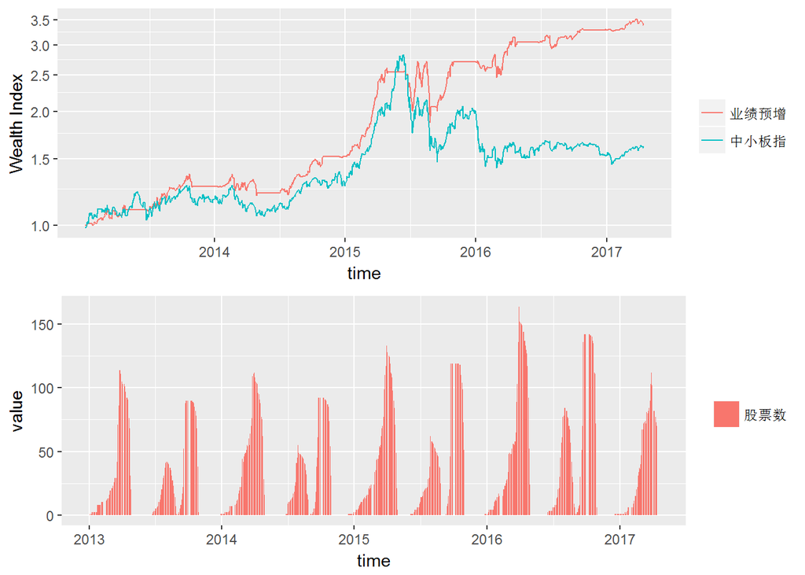

历年收益统计如下表所示。

|  | 业绩预增 | 中小板指 |
| --- | --- | --- |
| 2013-01-04 ~ 2013-12-31 | 26.6% | 17.5% |
| 2014-01-02 ~ 2014-12-31 | 20.1% | 9.7% |
| 2015-01-05 ~ 2015-12-31 | 77.9% | 53.7% |
| 2016-01-04 ~ 2016-12-30 | 22.0% | -22.9% |
| 2017-01-03 ~ 2017-04-14 | 2.5% | 4.7% |
| Cumulative Return | 238.1% | 59.9% |
| Annualized Return | 32.9% | 11.6% |

### (e)主动量化基金

主动量化基金最近一年和最近一个季度的收益率密度图如下所示。

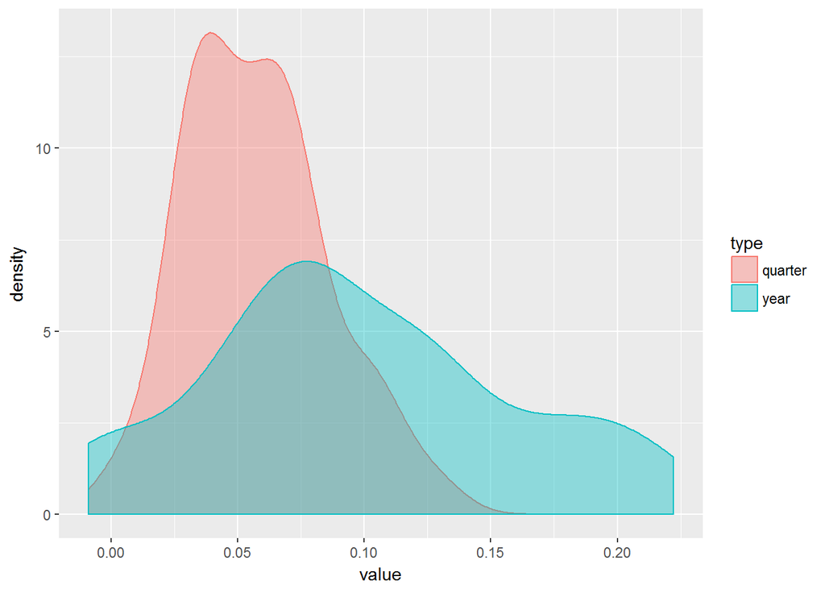

主动量化基金近一年和近一个季度表现最好的20只基金如下表所示。

| 季度排名 | 基金简称 | 成立日 | 总规模 | 季度收益 | 年度排名 | 基金简称 | 成立日 | 总规模 | 年度收益 |
| --- | --- | --- | --- | --- | --- | --- | --- | --- | --- |
| 1 | 泰达宏利量化 | 2016-08-30 | 2.0 | 13.2% | 1 | 华泰柏瑞量化优选 | 2014-12-17 | 3.1 | 22.2% |
| 2 | 景顺长城量化新动力 | 2016-07-13 | 1.0 | 12.1% | 2 | 泰达宏利同顺大数据A | 2016-02-23 | 2.1 | 20.9% |
| 3 | 景顺长城量化精选 | 2015-02-04 | 10.0 | 11.1% | 3 | 华泰柏瑞量化先行 | 2010-06-22 | 3.4 | 20.2% |
| 4 | 华泰柏瑞量化先行 | 2010-06-22 | 3.4 | 10.8% | 4 | 华泰柏瑞量化智慧 | 2015-06-03 | 3.7 | 20.0% |
| 5 | 华泰柏瑞量化智慧 | 2015-06-03 | 3.7 | 10.5% | 5 | 九泰久盛量化先锋 | 2015-11-10 | 3.2 | 18.2% |
| 6 | 长盛量化红利策略 | 2009-11-25 | 19.1 | 10.2% | 6 | 华泰柏瑞量化驱动 | 2015-03-24 | 14.3 | 17.9% |
| 7 | 工银瑞信量化策略 | 2012-04-26 | 1.4 | 9.9% | 7 | 华泰柏瑞量化A | 2013-08-02 | 32.3 | 17.1% |
| 8 | 泰达宏利同顺大数据A | 2016-02-23 | 2.1 | 9.8% | 8 | 泰达宏利逆向策略 | 2012-05-23 | 18.8 | 16.1% |
| 9 | 建信多因子量化 | 2016-08-09 | 2.5 | 9.3% | 9 | 景顺长城量化精选 | 2015-02-04 | 10.0 | 14.6% |
| 10 | 华泰柏瑞量化优选 | 2014-12-17 | 3.1 | 8.6% | 10 | 泰达宏利改革动力A | 2015-02-13 | 21.4 | 13.3% |
| 11 | 中海量化策略 | 2009-06-24 | 0.7 | 8.4% | 11 | 南方量化成长 | 2015-06-29 | 12.9 | 12.8% |
| 12 | 华泰柏瑞量化驱动 | 2015-03-24 | 14.3 | 7.9% | 12 | 大成核心双动力 | 2010-06-22 | 3.1 | 12.5% |
| 13 | 金鹰量化精选 | 2016-08-25 | 0.2 | 7.8% | 13 | 长信量化先锋A | 2010-11-18 | 109.4 | 12.4% |
| 14 | 长信量化多策略 | 2015-07-14 | 2.1 | 7.8% | 14 | 申万菱信量化小盘 | 2011-06-16 | 26.5 | 12.3% |
| 15 | 泰达宏利改革动力A | 2015-02-13 | 21.4 | 7.7% | 15 | 长信量化多策略 | 2015-07-14 | 2.1 | 12.3% |
| 16 | 华泰柏瑞量化A | 2013-08-02 | 32.3 | 7.7% | 16 | 华富量子生命力 | 2011-04-01 | 0.8 | 12.0% |
| 17 | 融通新趋势 | 2016-08-17 | 3.5 | 7.5% | 17 | 南方策略优化 | 2010-03-30 | 15.0 | 11.1% |
| 18 | 汇添富成长多因子量化策略 | 2015-02-16 | 17.6 | 7.2% | 18 | 华商大盘量化精选 | 2013-04-09 | 11.4 | 9.5% |
| 19 | 东兴量化多策略 | 2016-10-27 | 1.6 | 7.1% | 19 | 长盛量化红利策略 | 2009-11-25 | 19.1 | 9.3% |
| 20 | 永赢量化灵活配置 | 2015-09-01 | 0.6 | 7.0% | 20 | 嘉实腾讯自选股大数据 | 2015-12-07 | 6.9 | 9.3% |

## D、择时

### (a)等权指数

从历史来看，A股市场存在小盘股效应，市值小的股票长期整体跑赢大市值的股票，美股市场同样存在类似的现象。而目前大部分指数的编制方案都是类似市值加权，为了抛去市值的影响，下面展示几个等权指数，其中中证500等权和沪深300等权是现有的指数，中证全指等权是自己编制的指数。等权指数可以视为一个更好地业绩比较基准。等权指数走势如下图：

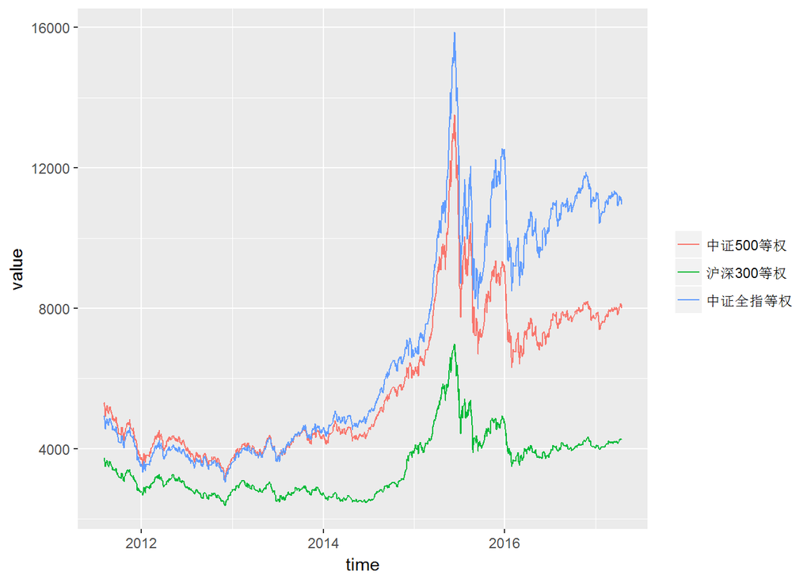

等权指数收益率统计见下表：

|  | 中证500等权 | 沪深300等权 | 中证全指等权 |
| --- | --- | --- | --- |
| 2011-08-02 ~ 2011-12-30 | -29.2% | -25.5% | -27.8% |
| 2012-01-04 ~ 2012-12-31 | -0.0% | 1.5% | 2.2% |
| 2013-01-04 ~ 2013-12-31 | 16.7% | -3.2% | 25.8% |
| 2014-01-02 ~ 2014-12-31 | 40.2% | 43.7% | 46.0% |
| 2015-01-05 ~ 2015-12-31 | 47.6% | 20.1% | 84.4% |
| 2016-01-04 ~ 2016-12-30 | -15.1% | -15.1% | -10.3% |
| 2017-01-03 ~ 2017-04-14 | 3.9% | 5.6% | -0.9% |
| 累计收益率 | 50.8% | 13.4% | 122.3% |
| 年化收益率 | 7.5% | 2.2% | 15.0% |
| 年化波动率 | 28.7% | 26.0% | 29.0% |
| 年化Sharpe值 | 26.0% | 8.6% | 51.7% |
| 最大回撤 | 53.3% | 50.0% | 49.7% |

### (b)大盘均线强弱指数

大盘均线强弱指数在一定程度上可以视为一个反转指标，当大盘均线得分接近8分时，预示市场接近顶部，当大盘均线得分接近0分时，预示市场接近底部。  
大盘均线强弱指数近一年来走势如下图：

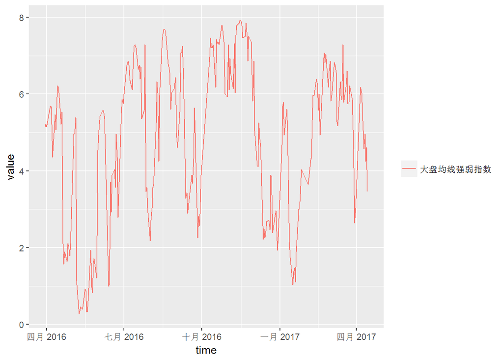

申万一级行业的最新得分见下表：

| 日期 | 指数代码 | 行业 | 最新得分 | 上周得分 |
| --- | --- | --- | --- | --- |
| 2017-04-14 | EI801040 | 钢铁 | 8 | 8 |
| 2017-04-14 | EI801160 | 公用事业 | 8 | 8 |
| 2017-04-14 | EI801170 | 交通运输 | 8 | 8 |
| 2017-04-14 | EI801180 | 房地产 | 8 | 8 |
| 2017-04-14 | EI801710 | 建筑材料 | 8 | 8 |
| 2017-04-14 | EI801740 | 国防军工 | 8 | 8 |
| 2017-04-14 | EI801020 | 采掘 | 7 | 8 |
| 2017-04-14 | EI801050 | 有色金属 | 7 | 6 |
| 2017-04-14 | EI801720 | 建筑装饰 | 7 | 8 |
| 2017-04-14 | EI801110 | 家用电器 | 4 | 5 |
| 2017-04-14 | EI801120 | 食品饮料 | 4 | 5 |
| 2017-04-14 | EI801730 | 电气设备 | 4 | 6 |
| 2017-04-14 | EI801880 | 汽车 | 4 | 8 |
| 2017-04-14 | EI801890 | 机械设备 | 4 | 5 |
| 2017-04-14 | EI801080 | 电子 | 3 | 5 |
| 2017-04-14 | EI801030 | 化工 | 1 | 4 |
| 2017-04-14 | EI801140 | 轻工制造 | 1 | 4 |
| 2017-04-14 | EI801200 | 商业贸易 | 1 | 1 |
| 2017-04-14 | EI801230 | 综合 | 1 | 2 |
| 2017-04-14 | EI801780 | 银行 | 1 | 2 |
| 2017-04-14 | EI801010 | 农林牧渔 | 0 | 0 |
| 2017-04-14 | EI801130 | 纺织服装 | 0 | 0 |
| 2017-04-14 | EI801150 | 医药生物 | 0 | 2 |
| 2017-04-14 | EI801210 | 休闲服务 | 0 | 6 |
| 2017-04-14 | EI801750 | 计算机 | 0 | 1 |
| 2017-04-14 | EI801760 | 传媒 | 0 | 0 |
| 2017-04-14 | EI801770 | 通信 | 0 | 2 |
| 2017-04-14 | EI801790 | 非银金融 | 0 | 0 |

### (c)LLT及均线择时

LLT本质上是一个改进的单均线择时指标，较原始的均线择时延迟更低。  
择时模型和指数本身的净值走势如下图：

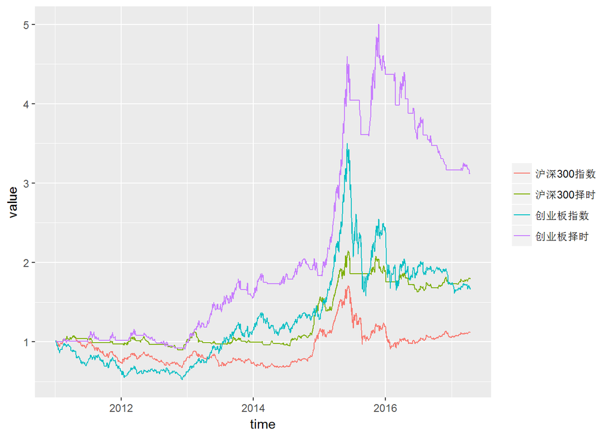

择时模型和指数的收益率统计如下表：

|  | 沪深300指 | 沪深300LLT | 创业板指 | 创业板MA |
| --- | --- | --- | --- | --- |
| 2011-01-04 ~ 2011-12-30 | -25.0% | -2.5% | -35.9% | 1.9% |
| 2012-01-04 ~ 2012-12-31 | 7.6% | 5.4% | -2.1% | -1.7% |
| 2013-01-04 ~ 2013-12-31 | -7.6% | -3.2% | 82.7% | 55.7% |
| 2014-01-02 ~ 2014-12-31 | 51.7% | 52.4% | 12.8% | 17.7% |
| 2015-01-05 ~ 2015-12-31 | 5.6% | 24.3% | 84.4% | 138.1% |
| 2016-01-04 ~ 2016-12-30 | -11.3% | -8.1% | -27.7% | -27.5% |
| 2017-01-03 ~ 2017-04-14 | 5.3% | 3.1% | -3.8% | -1.6% |
| 累计收益率 | 11.5% | 78.8% | 65.9% | 211.7% |
| 年化收益率 | 1.7% | 9.7% | 8.4% | 19.8% |
| 年化波动率 | 24.1% | 15.4% | 32.8% | 22.0% |
| 年化Sharpe值 | 7.2% | 62.7% | 25.6% | 90.0% |
| 最大回撤 | 46.7% | 24.0% | 54.9% | 37.7% |

择时模型最近10个交易日的信号如下表：

| 日期 | 沪深300收盘价 | 沪深300LLT | 沪深300择时信号 | 创业板收盘价 | 创业板MA30 | 创业板择时信号 |
| --- | --- | --- | --- | --- | --- | --- |
| 2017-03-30 | 3436.758 | 3465.624 | hold | 1893.701 | 1940.731 |  |
| 2017-03-31 | 3456.046 | 3465.633 | hold | 1907.338 | 1941.547 |  |
| 2017-04-05 | 3503.893 | 3467.805 | hold | 1943.160 | 1943.153 | buy |
| 2017-04-06 | 3514.047 | 3471.735 | hold | 1944.235 | 1943.925 | hold |
| 2017-04-07 | 3517.463 | 3475.893 | hold | 1946.049 | 1944.795 | hold |
| 2017-04-10 | 3505.139 | 3479.536 | hold | 1912.451 | 1944.345 | sell |
| 2017-04-11 | 3517.328 | 3482.974 | hold | 1917.633 | 1943.651 |  |
| 2017-04-12 | 3509.439 | 3486.360 | hold | 1897.507 | 1942.675 |  |
| 2017-04-13 | 3514.566 | 3489.467 | hold | 1910.476 | 1942.119 |  |
| 2017-04-14 | 3486.505 | 3491.653 | hold | 1887.460 | 1940.636 |  |

### (d)网格交易

在经历了三轮股灾，A股逐步回归正常，在过去的一段时间呈现一个震荡的格局，如果未来没有增量信息，很可能维持震荡。结合股指期货的贴水，前期研究了一下网格交易。网格交易的结果如下图：

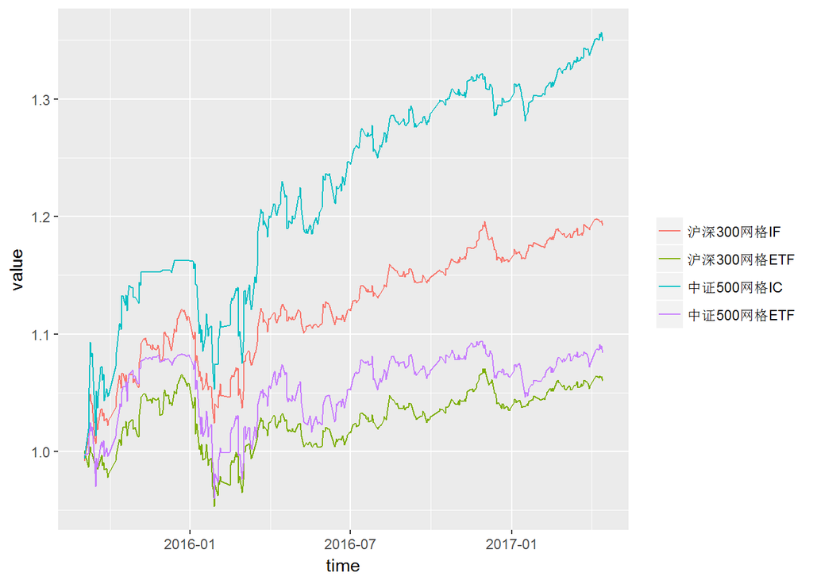

网格交易沪深300股指期货的最新仓位是33.8%，中证500股指期货的最新仓位是37.4%,网格交易的收益统计如下表：

|  | 沪深300指数 | 沪深300网格IF | 沪深300网格ETF | 中证500指数 | 中证500网格IC | 中证500网格ETF |
| --- | --- | --- | --- | --- | --- | --- |
| 2015-09-02 ~ 2015-12-31 | 11.0% | 11.1% | 5.6% | 23.5% | 16.2% | 8.1% |
| 2016-01-04 ~ 2016-12-30 | -11.3% | 4.7% | -1.8% | -17.8% | 11.8% | -1.6% |
| 2017-01-03 ~ 2017-04-14 | 5.3% | 2.5% | 2.3% | 4.2% | 3.8% | 1.9% |
| 累计收益率 | 3.7% | 19.2% | 6.0% | 5.8% | 34.9% | 8.4% |
| 年化收益率 | 2.3% | 11.5% | 3.7% | 3.6% | 20.3% | 5.1% |
| 年化波动率 | 21.6% | 9.1% | 8.8% | 29.2% | 13.3% | 11.4% |
| 年化Sharpe值 | 10.5% | 126.6% | 41.6% | 12.2% | 152.2% | 44.7% |
| 最大回撤 | 26.4% | 8.6% | 10.5% | 33.5% | 9.4% | 11.4% |

## E、选股

### (a)超级小盘股

作为多因子选股的第一部分，有必要从市值因子说起。 下面利用总市值因子，在中证全指的成分股内，选出市值最小的100只股票，这里剔除了ST、新上市、停牌和涨停的股票，100只股票等权配置，每月换仓一次，交易成本千分之三。超级小盘股策略的净值表现如下图。

[output not shown]

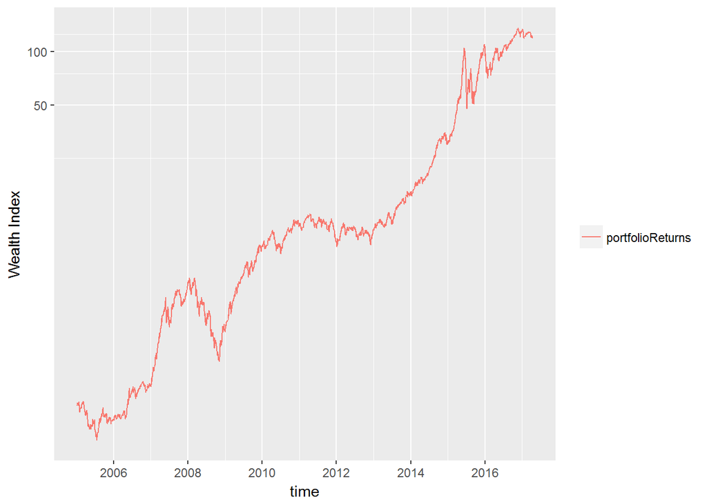

超级小盘股的收益统计如下表：

|  | 超级小盘股 | 沪深300 | 中证500 |
| --- | --- | --- | --- |
| 2005-01-05 ~ 2005-12-30 | -16.7% | -6.0% | -12.8% |
| 2006-01-04 ~ 2006-12-29 | 55.8% | 121.0% | 100.7% |
| 2007-01-04 ~ 2007-12-28 | 265.1% | 161.5% | 186.6% |
| 2008-01-02 ~ 2008-12-31 | -44.5% | -65.9% | -60.8% |
| 2009-01-05 ~ 2009-12-31 | 205.8% | 96.7% | 131.3% |
| 2010-01-04 ~ 2010-12-31 | 32.2% | -12.5% | 10.5% |
| 2011-01-04 ~ 2011-12-30 | -19.4% | -25.0% | -33.8% |
| 2012-01-04 ~ 2012-12-31 | 15.3% | 7.6% | 0.3% |
| 2013-01-04 ~ 2013-12-31 | 63.3% | -7.6% | 16.9% |
| 2014-01-02 ~ 2014-12-31 | 88.8% | 51.7% | 39.0% |
| 2015-01-05 ~ 2015-12-31 | 254.4% | 5.6% | 43.1% |
| 2016-01-04 ~ 2016-12-30 | 21.2% | -11.3% | -17.8% |
| 2017-01-03 ~ 2017-04-14 | -9.4% | 5.3% | 4.2% |
| 累计收益率 | 11741.4% | 254.8% | 563.7% |
| 年化收益率 | 47.6% | 10.9% | 16.7% |
| 年化波动率 | 35.7% | 28.4% | 32.4% |
| 年化Sharpe值 | 133.2% | 38.3% | 51.4% |
| 最大回撤 | 66.3% | 72.3% | 72.4% |

### (b)银行股轮动

银行股轮动是参考集思录的热门贴银行股评级而来的，数据的提取和参数的设置和原贴有一定的差别，所以轮动的效果也会不太一样，不过回测的效果还不错，从现在开始跟踪。2013年以来银行股轮动的结果如下图：

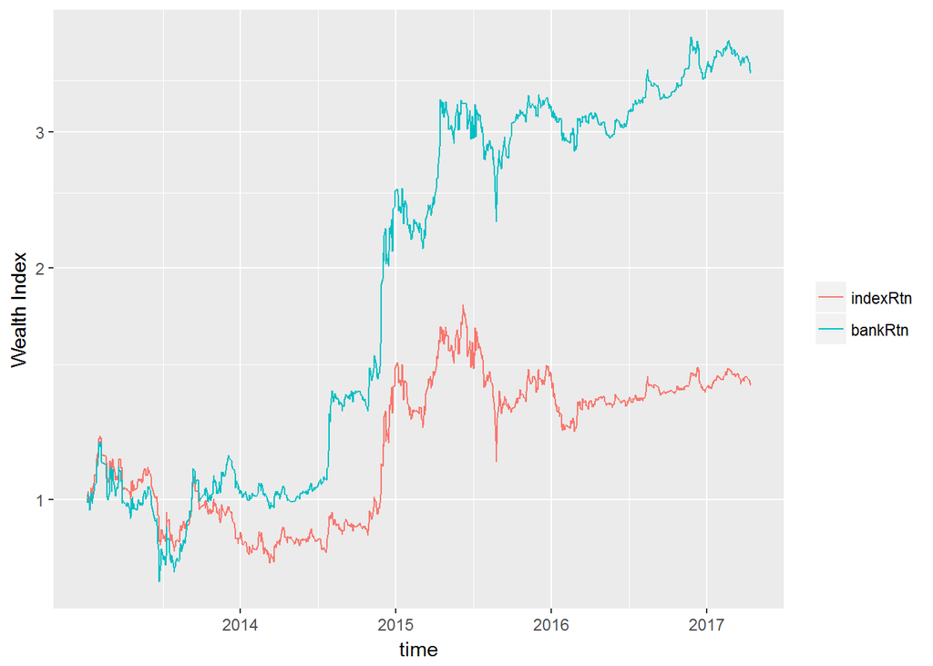

银行股轮动的收益统计如下表：

|  | 申万银行 | 银行股轮动 |
| --- | --- | --- |
| 2013-01-04 ~ 2013-12-31 | -9.2% | 3.0% |
| 2014-01-02 ~ 2014-12-31 | 63.2% | 144.5% |
| 2015-01-05 ~ 2015-12-31 | -1.4% | 29.0% |
| 2016-01-04 ~ 2016-12-30 | -4.9% | 10.5% |
| 2017-01-03 ~ 2017-04-14 | 1.3% | -0.3% |
| 累计收益率 | 40.7% | 258.0% |
| 年化收益率 | 8.3% | 34.7% |
| 年化波动率 | 28.1% | 32.0% |
| 年化Sharpe值 | 29.5% | 108.3% |
| 最大回撤 | 37.4% | 34.2% |

银行股轮动的最新得分如下表：

| 日期 | 代码 | 简称 | PB | 预期ROE | 翻倍期 | 持仓 |
| --- | --- | --- | --- | --- | --- | --- |
| 2017-04-14 | EQ600015 | 华夏银行 | 0.78 | 0.15 | 3.3 | hold |
| 2017-04-14 | EQ601818 | 光大银行 | 0.75 | 0.11 | 3.8 |  |
| 2017-04-14 | EQ601328 | 交通银行 | 0.72 | 0.10 | 3.8 |  |
| 2017-04-14 | EQ601988 | 中国银行 | 0.75 | 0.11 | 3.8 |  |
| 2017-04-14 | EQ601288 | 农业银行 | 0.82 | 0.13 | 4.0 |  |
| 2017-04-14 | EQ000001 | 平安银行 | 0.77 | 0.11 | 4.3 |  |
| 2017-04-14 | EQ601398 | 工商银行 | 0.87 | 0.13 | 4.4 |  |
| 2017-04-14 | EQ600016 | 民生银行 | 0.87 | 0.13 | 4.6 |  |
| 2017-04-14 | EQ600000 | 浦发银行 | 0.91 | 0.14 | 4.7 |  |
| 2017-04-14 | EQ601166 | 兴业银行 | 0.95 | 0.14 | 4.8 |  |
| 2017-04-14 | EQ601939 | 建设银行 | 0.93 | 0.14 | 4.8 |  |
| 2017-04-14 | EQ601998 | 中信银行 | 0.84 | 0.11 | 5.2 |  |
| 2017-04-14 | EQ601169 | 北京银行 | 1.02 | 0.13 | 5.8 |  |
| 2017-04-14 | EQ601009 | 南京银行 | 1.12 | 0.15 | 5.8 |  |
| 2017-04-14 | EQ600036 | 招商银行 | 1.18 | 0.15 | 6.2 |  |
| 2017-04-14 | EQ002142 | 宁波银行 | 1.34 | 0.16 | 6.5 |  |
| 2017-04-14 | EQ600919 | 江苏银行 | 1.34 | 0.13 | 8.2 |  |
| 2017-04-14 | EQ601997 | 贵阳银行 | 1.83 | 0.16 | 8.7 |  |
| 2017-04-14 | EQ601229 | 上海银行 | 1.34 | 0.12 | 8.7 |  |
| 2017-04-14 | EQ600926 | 杭州银行 | 1.62 | 0.10 | 11.9 |  |
| 2017-04-14 | EQ601128 | 常熟银行 | 3.10 | 0.10 | 18.4 |  |
| 2017-04-14 | EQ600908 | 无锡银行 | 3.11 | 0.10 | 19.2 |  |
| 2017-04-14 | EQ603323 | 吴江银行 | 2.72 | 0.08 | 21.9 |  |
| 2017-04-14 | EQ002807 | 江阴银行 | 4.64 | 0.09 | 27.3 |  |